# Statistics

Tour of statistical analysis in R

Eric Ekholm (CCPS Office of Research & Evaluation)  
2021-12-16

# Overview

This document is meant to provide some resources for conducting and reporting statistical analyses in R. We don’t go over everything possible, but we’ll discuss a handful of analyses that are pretty common, including:

- t-tests,
- correlations,
- linear regression, and
- logistic regression

We’ll use the `penguins` data from the `{palmerpenguins}` package to practice with these.

```r
knitr::opts_chunk$set(message = FALSE, warning = FALSE, fig.align = "center")

#loading useful packages
library(tidyverse)
library(palmerpenguins)
library(skimr) #install with install.packages("skimr") if you don't have already
library(psych) #install with install.packages("psych")

theme_set(theme_minimal())
```

# Descriptive Statistics

I won’t get too into the weeds here, but I will say that beyond the basic `mean()` and `sd()` functions in R, I really like the `skim()` function from the `{skimr}` package for getting a quick look at my data.

```r
skim(penguins)
```

Table 1: Data summary

| Name | penguins |
| --- | --- |
| Number of rows | 344 |
| Number of columns | 8 |
| _______________________ |  |
| Column type frequency: |  |
| factor | 3 |
| numeric | 5 |
| ________________________ |  |
| Group variables | None |

**Variable type: factor**

| skim_variable | n_missing | complete_rate | ordered | n_unique | top_counts |
| --- | --- | --- | --- | --- | --- |
| species | 0 | 1.00 | FALSE | 3 | Ade: 152, Gen: 124, Chi: 68 |
| island | 0 | 1.00 | FALSE | 3 | Bis: 168, Dre: 124, Tor: 52 |
| sex | 11 | 0.97 | FALSE | 2 | mal: 168, fem: 165 |

**Variable type: numeric**

| skim_variable | n_missing | complete_rate | mean | sd | p0 | p25 | p50 | p75 | p100 | hist |
| --- | --- | --- | --- | --- | --- | --- | --- | --- | --- | --- |
| bill_length_mm | 2 | 0.99 | 43.92 | 5.46 | 32.1 | 39.23 | 44.45 | 48.5 | 59.6 | ▃▇▇▆▁ |
| bill_depth_mm | 2 | 0.99 | 17.15 | 1.97 | 13.1 | 15.60 | 17.30 | 18.7 | 21.5 | ▅▅▇▇▂ |
| flipper_length_mm | 2 | 0.99 | 200.92 | 14.06 | 172.0 | 190.00 | 197.00 | 213.0 | 231.0 | ▂▇▃▅▂ |
| body_mass_g | 2 | 0.99 | 4201.75 | 801.95 | 2700.0 | 3550.00 | 4050.00 | 4750.0 | 6300.0 | ▃▇▆▃▂ |
| year | 0 | 1.00 | 2008.03 | 0.82 | 2007.0 | 2007.00 | 2008.00 | 2009.0 | 2009.0 | ▇▁▇▁▇ |

It’s also usually a good idea to graph your data before doing statistical analyses, but I’m going to skip that here.

# t-tests

We can test for differences in means between groups using the `t.test()` function. To conduct a two-sample t-test, we need to provide two different vectors with the data we want to compare.

Let’s see if male and female penguins have different body mass.

To do this, we first need to get two vectors: one with the mass of male penguins and one with the mass of female penguins:

```r
male_mass <- penguins$body_mass_g[penguins$sex == "male"]
female_mass <- penguins$body_mass_g[penguins$sex == "female"]
```

You can read the above as “male mass is a subset of the body_mass_g column in the penguins dataframe where the sex column in the penguins dataframe is equal to male.”

And once we have this, we can conduct our t-test!

```r
t_res <- t.test(male_mass, female_mass)
```

This will save the result of our analysis to the `t_res` object. We can print a summary of the results directly by just calling the object name:

```r
t_res
```

```
    Welch Two Sample t-test

data:  male_mass and female_mass
t = 8.5545, df = 323.9, p-value = 4.794e-16
alternative hypothesis: true difference in means is not equal to 0
95 percent confidence interval:
 526.2453 840.5783
sample estimates:
mean of x mean of y
 4545.685  3862.273
```

And we can see that there is a significant difference in these means. Males weigh (on average) about 4545 grams and females weigh (on average) about 3862 grams. Our p-value indicates that these values are significantly different.

We can also look at specific elements of our object result if we want. For instance, if we just want the p-value:

```r
t_res$p.value
```

```
[1] 4.793891e-16
```

# Correlations

Suppose we want to look at the correlations between penguins’ features. First, let’s just get the numeric variables in the dataframe to make this easier:

```r
penguins_numeric <- penguins %>%
  select(where(is.numeric), -year) #year is technically numeric, but let's not include it
```

The easiest way to look at correlations among these variables is just to pass this whole dataframe into the `cor()` function:

```r
cor(penguins_numeric)
```

```
                  bill_length_mm bill_depth_mm flipper_length_mm
bill_length_mm                 1            NA                NA
bill_depth_mm                 NA             1                NA
flipper_length_mm             NA            NA                 1
body_mass_g                   NA            NA                NA
                  body_mass_g
bill_length_mm             NA
bill_depth_mm              NA
flipper_length_mm          NA
body_mass_g                 1
```

Except this gives us a bunch of NA’s. This is because the default behavior of `cor()` is to use all of the observations. If these have any missing values, then the correlation coefficient will return as NA.

To get around this, we need to set the “use” option in the `cor()` function. There are a few options, but generally the one you’ll want is “pairwise.complete.obs”, which will use all of the complete observations between each pair of variables.

```r
cor(penguins_numeric, use = "pairwise.complete.obs")
```

```
                  bill_length_mm bill_depth_mm flipper_length_mm
bill_length_mm         1.0000000    -0.2350529         0.6561813
bill_depth_mm         -0.2350529     1.0000000        -0.5838512
flipper_length_mm      0.6561813    -0.5838512         1.0000000
body_mass_g            0.5951098    -0.4719156         0.8712018
                  body_mass_g
bill_length_mm      0.5951098
bill_depth_mm      -0.4719156
flipper_length_mm   0.8712018
body_mass_g         1.0000000
```

This gives us the correlation matrix. We can see, for example, that flipper length is strongly correlated (at r = .87) with body mass. If we want to save this matrix, we can assign it to an object.

```r
cor_res <- cor(penguins_numeric, use = "pairwise.complete.obs")
```

This `cor_res` object is a matrix (**not** a dataframe), so we have to access individual elements by their position if we want to extract them:

```r
cor_res[1, 2] #get the element in row 1, column 2
```

```
[1] -0.2350529
```

One thing that `cor()` doesn’t do, however, is test if each correlation is significantly different from 0. One way around this is to use the `cor.test()` function (that comes standard in base R). This requires you to pass in individual vectors to test (rather than an entire data frame):

```r
cor.test(penguins_numeric$body_mass_g, penguins_numeric$flipper_length_mm)
```

```
    Pearson's product-moment correlation

data:  penguins_numeric$body_mass_g and penguins_numeric$flipper_length_mm
t = 32.722, df = 340, p-value < 2.2e-16
alternative hypothesis: true correlation is not equal to 0
95 percent confidence interval:
 0.843041 0.894599
sample estimates:
      cor
0.8712018
```

Or you can use the `cor.ci()` function from the `{psych}` package and pass in the entire dataframe. This gives us a visual representation of the correlation matrix.

```r
cor_res2 <- cor.ci(penguins_numeric, use = "pairwise.complete.obs")
```

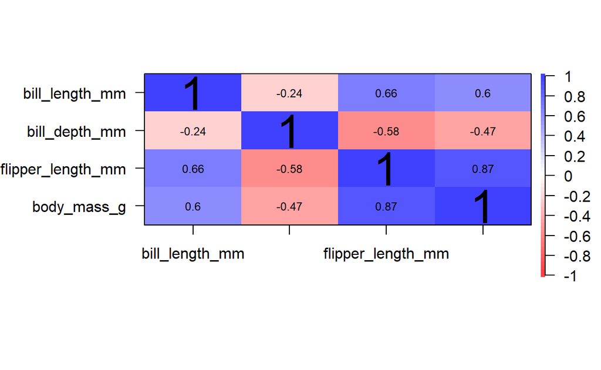

It will also give us p-values and confidence intervals for each of our correlation coefficients

```r
cor_res2
```

```
Call:corCi(x = x, keys = keys, n.iter = n.iter, p = p, overlap = overlap,
    poly = poly, method = method, plot = plot, minlength = minlength,
    n = n, use = "pairwise.complete.obs")

 Coefficients and bootstrapped confidence intervals
                  bll_l_ bll_d_ flp__ bdy__
bill_length_mm     1.00
bill_depth_mm     -0.24   1.00
flipper_length_mm  0.66  -0.58   1.00
body_mass_g        0.60  -0.47   0.87  1.00

 scale correlations and bootstrapped confidence intervals
              lower.emp lower.norm estimate upper.norm upper.emp p
bll_l_-bll_d_     -0.31      -0.32    -0.24      -0.14     -0.15 0
bll_l_-flp__       0.59       0.58     0.66       0.72      0.72 0
bll_l_-bdy__       0.52       0.52     0.60       0.66      0.66 0
bll_d_-flp__      -0.64      -0.63    -0.58      -0.53     -0.53 0
bll_d_-bdy__      -0.54      -0.53    -0.47      -0.41     -0.42 0
flp__-bdy__        0.84       0.85     0.87       0.89      0.89 0
```

# Linear Regression

And what if we wanted to look at predictive relationships between variables? For instance, say we wanted to look at the extent to which body mass is predicted by other features?

To do this, we can use the `lm()` function that’s built into R. `lm()` stands for **l**inear **m**odel, and it takes a few different arguments. The main ones we care about are:

- **formula**: the formula describing the regression we want to run,
- **data**: the data we want to run the regression on,
- **na.action**: what to do if the data has missing values

All said, our call might look like this:

```r
lm_res <- lm(body_mass_g ~ flipper_length_mm + sex, data = penguins, na.action = "na.omit")
```

Here, we’re running a regression where body_mass_g is the dependent variable, and flipper_length_mm and sex are the independent variables. We’re using the penguins data and omitting any rows that have NA’s on any of these variables. And we’re saving this to an object named lm_res.

If we just print out the object, we can see some information about the model:

```r
lm_res
```

```
Call:
lm(formula = body_mass_g ~ flipper_length_mm + sex, data = penguins,
    na.action = "na.omit")

Coefficients:
      (Intercept)  flipper_length_mm            sexmale
         -5410.30              46.98             347.85
```

In this case, a more useful way to look at the result is to call `summary()` on the result object. This will give use the coefficients for each of our predictors, the p-values of these coefficients, and the R-squared of the model (among other things).

```r
summary(lm_res)
```

```
Call:
lm(formula = body_mass_g ~ flipper_length_mm + sex, data = penguins,
    na.action = "na.omit")

Residuals:
    Min      1Q  Median      3Q     Max
-910.28 -243.89   -2.94  238.85 1067.73

Coefficients:
                   Estimate Std. Error t value Pr(>|t|)
(Intercept)       -5410.300    285.798 -18.931  < 2e-16 ***
flipper_length_mm    46.982      1.441  32.598  < 2e-16 ***
sexmale             347.850     40.342   8.623 2.78e-16 ***
---
Signif. codes:  0 '***' 0.001 '**' 0.01 '*' 0.05 '.' 0.1 ' ' 1

Residual standard error: 355.9 on 330 degrees of freedom
  (11 observations deleted due to missingness)
Multiple R-squared:  0.8058,    Adjusted R-squared:  0.8047
F-statistic: 684.8 on 2 and 330 DF,  p-value: < 2.2e-16
```

So, here we can see that for each mm increase in flipper length, we expect body mass to increase by about 47 grams in penguins of the same sex. We also expect (in penguins with the same flipper length) amles to have a body mass of about 348 grams more than females. And both of these effects are significant (which we can see in the Pr >|t| column).

Another nice thing about this `lm_res` object is that it has autoplot features built in. If we just call `plot()` on it, we can get a bunch of regression diagnostic plots.

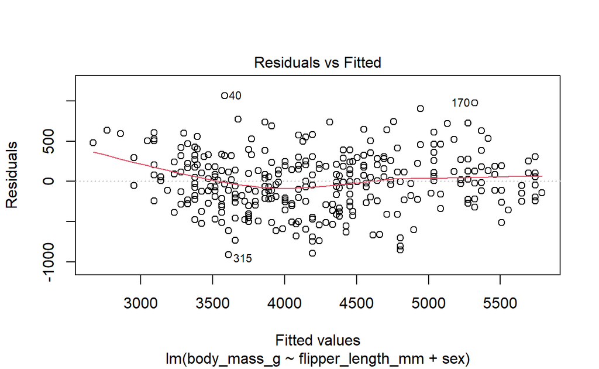

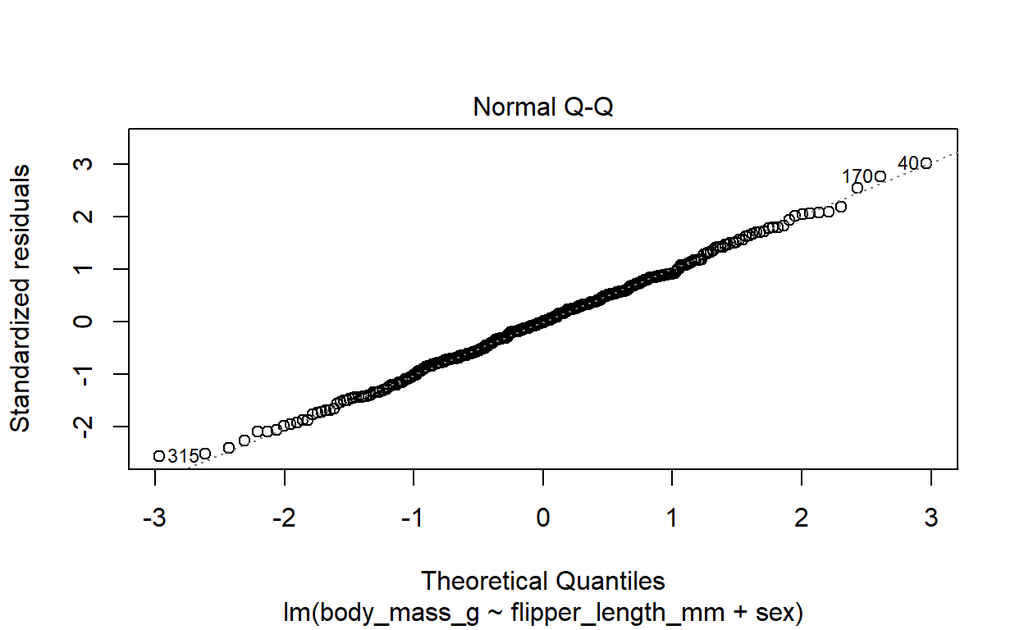

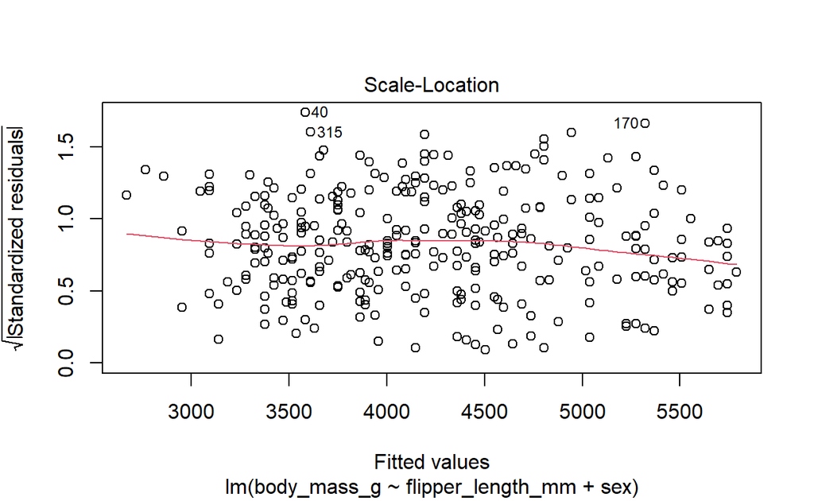

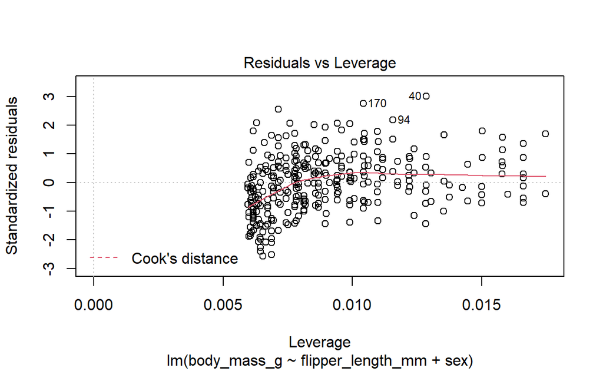

```r
plot(lm_res)
```

## Other LM Features

### Include all Variables

Another nice trick with the `lm()` function is that we can shortcut the formula a little bit with the . placeholder:

```r
lm(body_mass_g ~ ., data = penguins, na.action = "na.omit")
```

```
Call:
lm(formula = body_mass_g ~ ., data = penguins, na.action = "na.omit")

Coefficients:
      (Intercept)   speciesChinstrap      speciesGentoo
         84087.94            -282.54             890.96
      islandDream    islandTorgersen     bill_length_mm
           -21.18             -58.78              18.96
    bill_depth_mm  flipper_length_mm            sexmale
            60.80              18.50             378.98
             year
           -42.78
```

This tells lm to include all of the data (other than the dependent variable) as predictors in the model, which can save us some typing.

### Specify Interactions

You can also specify interactions directly in the formula. For instance, if we wanted to see if there’s an interaction between flipper length and sex in how they predict body mass, we could do the following:

```r
lm_res2 <- lm(body_mass_g ~ flipper_length_mm + sex + sex*flipper_length_mm, data = penguins,
              na.action = "na.omit")

summary(lm_res2)
```

```
Call:
lm(formula = body_mass_g ~ flipper_length_mm + sex + sex * flipper_length_mm,
    data = penguins, na.action = "na.omit")

Residuals:
    Min      1Q  Median      3Q     Max
-909.36 -246.58   -3.13  237.18 1065.19

Coefficients:
                            Estimate Std. Error t value Pr(>|t|)
(Intercept)               -5443.9607   440.2829 -12.365   <2e-16 ***
flipper_length_mm            47.1527     2.2264  21.179   <2e-16 ***
sexmale                     406.8015   587.3029   0.693    0.489
flipper_length_mm:sexmale    -0.2942     2.9242  -0.101    0.920
---
Signif. codes:  0 '***' 0.001 '**' 0.01 '*' 0.05 '.' 0.1 ' ' 1

Residual standard error: 356.4 on 329 degrees of freedom
  (11 observations deleted due to missingness)
Multiple R-squared:  0.8058,    Adjusted R-squared:  0.8041
F-statistic: 455.2 on 3 and 329 DF,  p-value: < 2.2e-16
```

So, here we can see that there’s not a significant interaction between sex and flipper length (i.e. the effect of flipper length on body mass doesn’t seem to differ between males and females).

# Logistic Regression

Finally, what if the outcome variable we wanted to predict was a binary (yes/no) variable? To do this, we’d want to run a logistic regression. If you’re interested in reading more about logistic regression, I really like [this article](https://scholarworks.umass.edu/pare/vol17/iss1/11/).

Running a logistic regression is remarkably similar to running a linear regression in R, except you use the `glm()` function (for **g**eneralized **l**inear **m**odel). Like the name suggests, `glm()` is useful for running several generalizations of the linear model, but the most common one (in our case) is logistic regression.

Let’s imagine we want to predict whether a penguin is male (where sex is a binary variable). We could run the following logistic regression:

```r
log_res <- glm(sex ~ body_mass_g + flipper_length_mm, data = penguins,
               family = "binomial")
```

Where we have the same type of formula as before (except with sex as the outcome), and a data argument. We also have a “family” argument that we need to specify. For logistic regression, the family we want to use is “binomial.”

Note that if you use a binary (2-value) factor variable as the outcome in a logistic regression, R will assume that the factor mapped to the largest underlying integer is the one you’re predicting (i.e. in our sex column, the underlying value of “male” is 2 and the underlying value of “female” is 1. You can compare `unclass(penguins$sex)` to `penguins$sex` to see this)

We can then view the results of this similar to how we did previously with the linear regression model:

```r
summary(log_res)
```

```
Call:
glm(formula = sex ~ body_mass_g + flipper_length_mm, family = "binomial",
    data = penguins)

Deviance Residuals:
    Min       1Q   Median       3Q      Max
-1.9901  -0.9598   0.2442   0.8898   2.1068

Coefficients:
                    Estimate Std. Error z value Pr(>|z|)
(Intercept)        7.0868039  2.6621921   2.662  0.00777 **
body_mass_g        0.0027820  0.0003923   7.092 1.32e-12 ***
flipper_length_mm -0.0932568  0.0199664  -4.671 3.00e-06 ***
---
Signif. codes:  0 '***' 0.001 '**' 0.01 '*' 0.05 '.' 0.1 ' ' 1

(Dispersion parameter for binomial family taken to be 1)

    Null deviance: 461.61  on 332  degrees of freedom
Residual deviance: 371.98  on 330  degrees of freedom
  (11 observations deleted due to missingness)
AIC: 377.98

Number of Fisher Scoring iterations: 4
```

So what does this tell us? Both body mass and flipper length are significantly related to penguin sex. It also tells us that as body mass increases, the log odds of being a male increase (by .002 for each 1 gram increase in mass). Likewise, the log odds of being a male decrease by .09 for each 1mm increase in flipper length. We can convert these into odds to make them slightly easier to interpret by exponentiating them:

```r
exp(log_res$coefficients)
```

```
      (Intercept)       body_mass_g flipper_length_mm
     1196.0789489         1.0027859         0.9109595
```

# Further Reading

We haven’t touched on it yet, but the Rstudio team has a whole framework built around statistics and modeling. The collection of packages is called [`{tidymodels}`](https://www.tidymodels.org/), and you can check out their website and learning resources if you want to dig into that stuff.